# Session 3 extension: exploratory factor analysis

Latent variables and data reduction for correlated items

O Rodriguez de Rivera Ortega, PhD

University of Exeter

# 1 Session overview

## 1.1 What is this session about?

This optional extension introduces **exploratory factor analysis**, often abbreviated to **EFA**.

EFA is used when we have several observed variables that may be measuring a smaller number of underlying, unobserved concepts.

These underlying concepts are called **latent factors**.

For example, in a questionnaire, we may ask many questions about behaviour, opinions or attitudes. Some questions may be related because they are all measuring the same underlying construct.

The main question in EFA is:

> Can the correlations among many observed variables be explained by a smaller number of latent factors?

In this session, we use the `bfi` dataset from the `psych` package. This dataset contains responses to personality questionnaire items. We use it as a convenient teaching example of correlated item data.

## 1.2 Learning outcomes

By the end of this extension, students should be able to:

- explain what a latent factor is;
- distinguish PCA from EFA;
- inspect correlations among questionnaire-style items;
- assess whether factor analysis is reasonable;
- use parallel analysis to guide the number of factors;
- fit an EFA model using `psych::fa()`;
- interpret rotated factor loadings;
- understand the purpose of factor rotation;
- extract and visualise factor scores;
- compare alternative factor solutions.

# 2 EFA in context

## 2.1 Continuity from PCA

Earlier in the session, PCA was used to reduce several continuous variables into a smaller number of components.

PCA creates components that maximise explained variance in the observed variables.

Exploratory factor analysis asks a slightly different question:

> Are the correlations among observed variables driven by a smaller number of latent factors?

The difference is subtle but important.

PCA is mainly a **data reduction** method. EFA is more of a **measurement model**. It is often used when we believe the observed variables are indicators of underlying constructs.

## 2.2 PCA versus EFA

| PCA | EFA |
| --- | --- |
| Creates components | Estimates latent factors |
| Components are weighted combinations of observed variables | Factors are assumed to explain correlations among observed variables |
| Focuses on total variance | Focuses on shared variance |
| Often used for dimension reduction | Often used for questionnaire or psychological constructs |
| Components are mathematical summaries | Factors are interpreted as underlying constructs |

A simple way to explain the distinction is:

- PCA asks: *Can we summarise many variables with fewer components?*
- EFA asks: *Can we explain why variables are correlated using fewer latent factors?*

## 2.3 Example of latent factors

Suppose we ask students to rate these statements:

- I enjoy working with data.
- I feel confident using R.
- I like solving statistical problems.
- I avoid quantitative tasks.
- I feel anxious when interpreting model output.

Some items may reflect an underlying factor such as **statistical confidence**. Others may reflect **statistical anxiety**.

We do not observe these latent attitudes directly. Instead, we observe responses to questions that may be related to them.

EFA helps us explore whether such latent structure is present.

# 3 Setup

## 3.1 Packages

```r
install.packages(c("tidyverse", "psych", "GPArotation"))
```

```r
library(tidyverse)
library(psych)
library(GPArotation)

theme_set(theme_minimal(base_size = 12))
```

# 4 Load the data

## 4.1 Big Five Inventory data

```r
data("bfi", package = "psych")

bfi_items <- bfi %>%
  dplyr::select(A1:O5) %>%
  tidyr::drop_na()

dim(bfi_items)
```

```
## [1] 2436   25
```

The `bfi` dataset contains responses to personality questionnaire items.

The item names refer to broad personality domains:

- `A` items: agreeableness;
- `C` items: conscientiousness;
- `E` items: extraversion;
- `N` items: neuroticism;
- `O` items: openness.

For this session, we use the data mainly to illustrate the EFA workflow rather than to make substantive psychological claims.

## 4.2 Inspect the first rows

```r
dplyr::glimpse(bfi_items)
```

```
## Rows: 2,436
## Columns: 25
## $ A1 <int> 2, 2, 5, 4, 2, 6, 2, 4, 2, 4, 5, 5, 4, 4, 4, 5, 4, 4, 5, 1, 1, 2, 4…
## $ A2 <int> 4, 4, 4, 4, 3, 6, 5, 3, 5, 4, 5, 5, 5, 3, 6, 5, 4, 4, 4, 6, 5, 6, 5…
## $ A3 <int> 3, 5, 5, 6, 3, 5, 5, 1, 6, 5, 5, 5, 2, 6, 6, 5, 5, 6, 2, 6, 6, 5, 5…
## $ A4 <int> 4, 2, 4, 5, 4, 6, 3, 5, 6, 6, 6, 6, 2, 6, 2, 4, 4, 5, 1, 1, 5, 6, 6…
## $ A5 <int> 4, 5, 4, 5, 5, 5, 5, 1, 5, 5, 4, 6, 1, 3, 5, 5, 3, 5, 2, 5, 6, 5, 5…
## $ C1 <int> 2, 5, 4, 4, 4, 6, 5, 3, 6, 4, 5, 4, 5, 5, 4, 5, 5, 1, 4, 5, 4, 3, 5…
## $ C2 <int> 3, 4, 5, 4, 4, 6, 4, 2, 5, 3, 4, 4, 5, 5, 4, 5, 4, 1, 6, 4, 3, 5, 5…
## $ C3 <int> 3, 4, 4, 3, 5, 6, 4, 4, 6, 5, 3, 4, 5, 5, 4, 5, 5, 1, 5, 4, 2, 6, 4…
## $ C4 <int> 4, 3, 2, 5, 3, 1, 2, 2, 2, 3, 2, 2, 2, 3, 4, 4, 4, 5, 5, 2, 4, 3, 1…
## $ C5 <int> 4, 4, 5, 5, 2, 3, 3, 4, 1, 2, 2, 1, 2, 5, 4, 3, 6, 6, 4, 3, 5, 6, 1…
## $ E1 <int> 3, 1, 2, 5, 2, 2, 4, 3, 2, 1, 3, 2, 3, 1, 1, 2, 1, 1, 3, 1, 2, 2, 3…
## $ E2 <int> 3, 1, 4, 3, 2, 1, 3, 6, 2, 3, 3, 2, 4, 1, 2, 2, 2, 1, 3, 2, 1, 2, 2…
## $ E3 <int> 3, 6, 4, 4, 5, 6, 4, 4, 4, 2, 3, 4, 3, 6, 5, 4, 4, 4, 5, 4, 2, 4, 5…
## $ E4 <int> 4, 4, 4, 4, 4, 5, 5, 2, 5, 5, 2, 6, 6, 6, 5, 6, 5, 5, 5, 3, 5, 6, 5…
## $ E5 <int> 4, 3, 5, 4, 5, 6, 5, 1, 5, 4, 4, 5, 5, 4, 5, 6, 5, 6, 4, 4, 2, 6, 6…
## $ N1 <int> 3, 3, 4, 2, 2, 3, 1, 6, 5, 3, 1, 1, 2, 4, 4, 6, 5, 5, 1, 2, 2, 4, 2…
## $ N2 <int> 4, 3, 5, 5, 3, 5, 2, 3, 5, 3, 2, 1, 4, 5, 4, 5, 6, 5, 3, 5, 2, 4, 3…
## $ N3 <int> 2, 3, 4, 2, 4, 2, 2, 2, 5, 4, 2, 1, 2, 4, 4, 5, 5, 5, 3, 5, 2, 4, 3…
## $ N4 <int> 2, 5, 2, 4, 4, 2, 1, 6, 2, 2, 2, 2, 2, 5, 4, 4, 5, 1, 2, 4, 2, 6, 1…
## $ N5 <int> 3, 5, 3, 1, 3, 3, 1, 4, 4, 3, 2, 1, 3, 5, 5, 4, 2, 1, 1, 6, 2, 6, 1…
## $ O1 <int> 3, 4, 4, 3, 3, 4, 5, 3, 5, 5, 4, 5, 5, 6, 5, 5, 4, 4, 6, 5, 6, 6, 6…
## $ O2 <int> 6, 2, 2, 3, 3, 3, 2, 2, 1, 3, 2, 3, 2, 6, 1, 1, 2, 1, 1, 1, 1, 1, 2…
## $ O3 <int> 3, 4, 5, 4, 4, 5, 5, 4, 5, 5, 4, 4, 5, 6, 5, 4, 2, 5, 3, 6, 5, 5, 5…
## $ O4 <int> 4, 3, 5, 3, 3, 6, 6, 5, 5, 6, 5, 4, 5, 3, 6, 5, 4, 3, 2, 6, 5, 6, 6…
## $ O5 <int> 3, 3, 2, 5, 3, 1, 1, 3, 2, 3, 2, 4, 5, 2, 3, 4, 2, 2, 4, 2, 2, 1, 2…
```

```r
head(bfi_items)
```

```
##   A1 A2 A3 A4 A5 C1 C2 C3 C4 C5 E1 E2 E3 E4 E5 N1 N2 N3 N4 N5 O1 O2 O3 O4 O5
## 1  2  4  3  4  4  2  3  3  4  4  3  3  3  4  4  3  4  2  2  3  3  6  3  4  3
## 2  2  4  5  2  5  5  4  4  3  4  1  1  6  4  3  3  3  3  5  5  4  2  4  3  3
## 3  5  4  5  4  4  4  5  4  2  5  2  4  4  4  5  4  5  4  2  3  4  2  5  5  2
## 4  4  4  6  5  5  4  4  3  5  5  5  3  4  4  4  2  5  2  4  1  3  3  4  3  5
## 5  2  3  3  4  5  4  4  5  3  2  2  2  5  4  5  2  3  4  4  3  3  3  4  3  3
## 6  6  6  5  6  5  6  6  6  1  3  2  1  6  5  6  3  5  2  2  3  4  3  5  6  1
```

Each row represents a respondent. Each column is an item response.

The aim is to explore whether the 25 items can be represented by a smaller number of latent factors.

# 5 Explore correlations

## 5.1 Why correlations matter

EFA is based on the correlation structure among observed variables.

If items are not correlated with each other, there is little reason to fit a factor model.

If groups of items are moderately correlated, this may suggest that they share an underlying factor.

## 5.2 Correlation matrix

```r
bfi_cor <- cor(bfi_items)

round(bfi_cor[1:8, 1:8], 2)
```

```
##       A1    A2    A3    A4    A5   C1   C2    C3
## A1  1.00 -0.35 -0.27 -0.16 -0.19 0.01 0.01 -0.02
## A2 -0.35  1.00  0.50  0.35  0.40 0.10 0.13  0.19
## A3 -0.27  0.50  1.00  0.38  0.52 0.11 0.15  0.13
## A4 -0.16  0.35  0.38  1.00  0.33 0.09 0.23  0.13
## A5 -0.19  0.40  0.52  0.33  1.00 0.13 0.12  0.13
## C1  0.01  0.10  0.11  0.09  0.13 1.00 0.44  0.32
## C2  0.01  0.13  0.15  0.23  0.12 0.44 1.00  0.36
## C3 -0.02  0.19  0.13  0.13  0.13 0.32 0.36  1.00
```

The correlation matrix shows pairwise correlations among items.

Positive correlations mean that respondents who score high on one item also tend to score high on another.

Negative correlations mean that respondents who score high on one item tend to score low on another.

## 5.3 Correlation heatmap

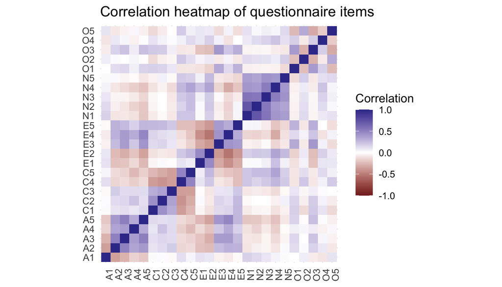

```r
bfi_cor %>%
  as.data.frame() %>%
  tibble::rownames_to_column("item1") %>%
  tidyr::pivot_longer(
    cols = -item1,
    names_to = "item2",
    values_to = "correlation"
  ) %>%
  ggplot(aes(x = item1, y = item2, fill = correlation)) +
  geom_tile() +
  scale_fill_gradient2(
    limits = c(-1, 1),
    midpoint = 0
  ) +
  coord_equal() +
  theme(
    axis.text.x = element_text(angle = 90, hjust = 1)
  ) +
  labs(
    title = "Correlation heatmap of questionnaire items",
    x = NULL,
    y = NULL,
    fill = "Correlation"
  )
```

## 5.4 Interpreting the heatmap

The heatmap helps us see whether there are blocks of correlated items.

Blocks of high positive or negative correlation may suggest that groups of items are measuring related constructs.

However, the heatmap is only exploratory. It does not tell us directly how many factors to fit.

# 6 Is factor analysis appropriate?

## 6.1 Factorability

Before fitting an EFA model, it is useful to ask whether the correlation matrix is suitable for factor analysis.

Two common checks are:

- the Kaiser-Meyer-Olkin measure, often called KMO;
- Bartlett’s test of sphericity.

The KMO statistic measures whether correlations are sufficiently patterned for factor analysis.

Bartlett’s test checks whether the correlation matrix differs from an identity matrix. If the matrix were close to identity, variables would be mostly uncorrelated and factor analysis would not be useful.

```r
psych::KMO(bfi_cor)
```

```
## Kaiser-Meyer-Olkin factor adequacy
## Call: psych::KMO(r = bfi_cor)
## Overall MSA =  0.85
## MSA for each item =
##   A1   A2   A3   A4   A5   C1   C2   C3   C4   C5   E1   E2   E3   E4   E5   N1
## 0.75 0.84 0.87 0.88 0.90 0.84 0.80 0.85 0.83 0.86 0.84 0.88 0.90 0.88 0.89 0.78
##   N2   N3   N4   N5   O1   O2   O3   O4   O5
## 0.78 0.86 0.89 0.86 0.86 0.78 0.84 0.77 0.76
```

```r
psych::cortest.bartlett(
  R = bfi_cor,
  n = nrow(bfi_items)
)
```

```
## $chisq
## [1] 18146.07
##
## $p.value
## [1] 0
##
## $df
## [1] 300
```

These checks should not be used mechanically. They are helpful diagnostics, but interpretation should also consider the research question and item design.

# 7 Number of factors

## 7.1 Why choosing the number of factors matters

Choosing the number of factors is one of the most important decisions in EFA.

Too few factors may combine distinct constructs. Too many factors may split one construct into several artificial pieces.

There is rarely one perfect answer. We usually combine:

- statistical criteria;
- interpretability of loadings;
- theoretical expectations;
- simplicity.

## 7.2 Parallel analysis

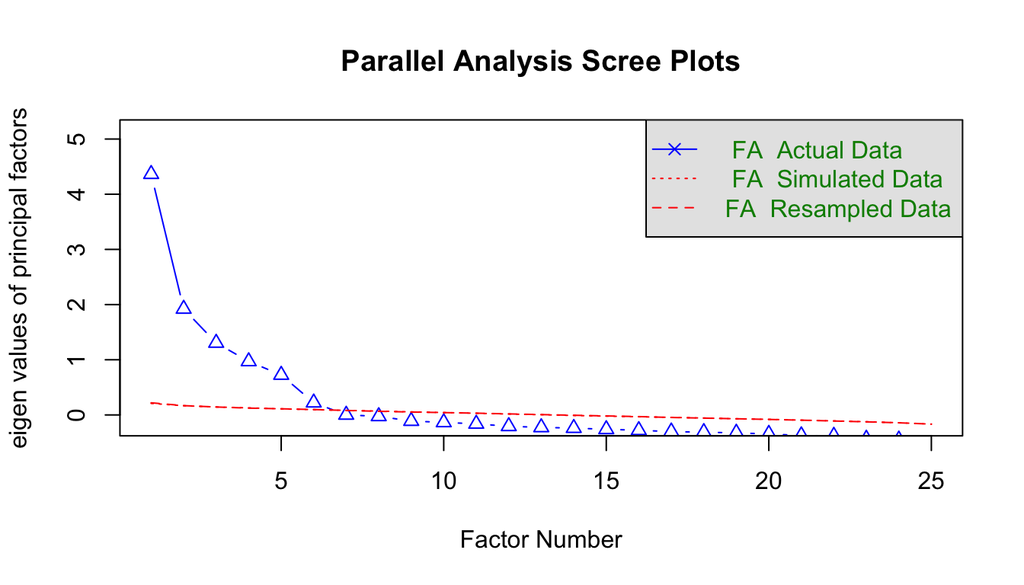

```
## Parallel analysis suggests that the number of factors =  6  and the number of components =  NA
```

```r
set.seed(123)

psych::fa.parallel(
  bfi_items,
  fa = "fa",
  fm = "minres",
  n.iter = 20
)
```

Parallel analysis compares the observed eigenvalues with eigenvalues expected from random data.

The basic idea is:

> Keep factors whose observed eigenvalues are larger than what would be expected by chance.

Parallel analysis gives guidance, but the final decision should also consider whether the factor solution is interpretable.

# 8 Fit EFA

## 8.1 Five-factor solution

The `bfi` data are designed around five broad personality domains, so a five-factor solution is a natural teaching example.

```r
efa_fit <- psych::fa(
  bfi_items,
  nfactors = 5,
  fm = "minres",
  rotate = "oblimin",
  scores = "regression"
)

efa_fit
```

```
## Factor Analysis using method =  minres
## Call: psych::fa(r = bfi_items, nfactors = 5, rotate = "oblimin", scores = "regression",
##     fm = "minres")
## Standardized loadings (pattern matrix) based upon correlation matrix
##      MR5   MR2   MR4   MR3   MR1   h2   u2 com
## A1  0.20 -0.18  0.07 -0.44 -0.05 0.20 0.80 1.9
## A2 -0.02  0.00  0.07  0.66  0.03 0.46 0.54 1.0
## A3 -0.02 -0.10  0.03  0.68  0.03 0.54 0.46 1.1
## A4 -0.05 -0.08  0.19  0.45 -0.16 0.30 0.70 1.7
## A5 -0.12 -0.23  0.00  0.54  0.05 0.47 0.53 1.5
## C1  0.07  0.03  0.55  0.00  0.16 0.35 0.65 1.2
## C2  0.15  0.09  0.67  0.08  0.04 0.45 0.55 1.2
## C3  0.03  0.06  0.57  0.09 -0.07 0.32 0.68 1.1
## C4  0.16  0.00 -0.64  0.04 -0.04 0.48 0.52 1.1
## C5  0.18  0.15 -0.56  0.02  0.10 0.44 0.56 1.4
## E1 -0.06  0.55  0.10 -0.09 -0.10 0.35 0.65 1.2
## E2  0.09  0.67 -0.02 -0.06 -0.07 0.55 0.45 1.1
## E3  0.09 -0.41  0.00  0.24  0.30 0.44 0.56 2.7
## E4  0.00 -0.59  0.02  0.30 -0.06 0.54 0.46 1.5
## E5  0.16 -0.42  0.27  0.06  0.22 0.41 0.59 2.7
## N1  0.83 -0.11  0.00 -0.11 -0.05 0.68 0.32 1.1
## N2  0.78 -0.03  0.01 -0.09  0.02 0.61 0.39 1.0
## N3  0.70  0.11 -0.03  0.08  0.02 0.54 0.46 1.1
## N4  0.47  0.40 -0.14  0.10  0.08 0.51 0.49 2.3
## N5  0.48  0.21  0.00  0.20 -0.16 0.35 0.65 2.0
## O1  0.01 -0.09  0.07  0.01  0.52 0.32 0.68 1.1
## O2  0.19 -0.07 -0.08  0.16 -0.47 0.27 0.73 1.7
## O3  0.03 -0.15  0.01  0.08  0.62 0.47 0.53 1.2
## O4  0.11  0.33 -0.03  0.17  0.36 0.25 0.75 2.6
## O5  0.12 -0.10 -0.03  0.05 -0.54 0.30 0.70 1.2
##
##                        MR5  MR2  MR4  MR3  MR1
## SS loadings           2.58 2.21 2.10 2.07 1.64
## Proportion Var        0.10 0.09 0.08 0.08 0.07
## Cumulative Var        0.10 0.19 0.28 0.36 0.42
## Proportion Explained  0.24 0.21 0.20 0.20 0.15
## Cumulative Proportion 0.24 0.45 0.65 0.85 1.00
##
##  With factor correlations of
##       MR5   MR2   MR4   MR3   MR1
```

[output cut: 12 more lines]

```
## The root mean square of the residuals (RMSR) is  0.03
## The df corrected root mean square of the residuals is  0.04
##
## The harmonic n.obs is  2436 with the empirical chi square  565.95  with prob <  3.1e-40
## The total n.obs was  2436  with Likelihood Chi Square =  1538.52  with prob <  8.6e-212
##
## Tucker Lewis Index of factoring reliability =  0.877
## RMSEA index =  0.055  and the 90 % confidence intervals are  0.052 0.057
## BIC =  95.87
## Fit based upon off diagonal values = 0.98
## Measures of factor score adequacy
##                                                    MR5  MR2  MR4  MR3  MR1
## Correlation of (regression) scores with factors   0.91 0.82 0.84 0.83 0.82
## Multiple R square of scores with factors          0.83 0.67 0.71 0.68 0.66
## Minimum correlation of possible factor scores     0.66 0.34 0.43 0.36 0.33
```

## 8.2 Model choices

In this model:

- `nfactors = 5` asks for five latent factors;
- `fm = "minres"` uses minimum residual factor extraction;
- `rotate = "oblimin"` uses an oblique rotation;
- `scores = "regression"` estimates factor scores for respondents.

Oblique rotation allows factors to be correlated. This is often realistic for questionnaire data because psychological or behavioural constructs are rarely completely independent.

# 9 Interpreting loadings

## 9.1 What is a factor loading?

A **factor loading** describes the relationship between an observed item and a latent factor.

Large positive loadings mean that the item is strongly positively associated with the factor.

Large negative loadings mean that the item is strongly negatively associated with the factor.

Small loadings mean that the item is weakly related to that factor.

A common rule of thumb is to focus on loadings with absolute value greater than about 0.3, although this threshold is not universal.

## 9.2 Loadings table

```r
print(efa_fit$loadings, cutoff = 0.3)
```

```
##
## Loadings:
##    MR5    MR2    MR4    MR3    MR1
## A1                      -0.435
## A2                       0.656
## A3                       0.678
## A4                       0.448
## A5                       0.537
## C1                0.555
## C2                0.669
## C3                0.574
## C4               -0.644
## C5               -0.563
## E1         0.555
## E2         0.667
## E3        -0.408                0.302
## E4        -0.587
## E5        -0.418
## N1  0.832
## N2  0.780
## N3  0.703
## N4  0.471  0.405
## N5  0.483
## O1                              0.518
## O2                             -0.473
## O3                              0.619
## O4         0.335                0.363
## O5                             -0.540
##
##                  MR5   MR2   MR4   MR3   MR1
## SS loadings    2.504 1.962 1.979 1.890 1.562
## Proportion Var 0.100 0.078 0.079 0.076 0.062
## Cumulative Var 0.100 0.179 0.258 0.333 0.396
```

## 9.3 How to read the loadings

To interpret a factor:

1. Look down one factor column.
2. Identify the items with the largest positive or negative loadings.
3. Ask what those items have in common.
4. Give the factor a tentative label.

Factor labels are not estimated by the model. They are chosen by the researcher.

For example, if several items related to sociability load strongly on one factor, we may interpret that factor as something like **extraversion**.

## 9.4 Communality and uniqueness

EFA also gives information about how well each item is represented by the factors.

- **Communality** is the proportion of item variance explained by the factors.
- **Uniqueness** is the proportion of item variance not explained by the factors.

Items with high uniqueness are not well explained by the factor model.

```r
item_fit <- tibble::tibble(
  item = rownames(efa_fit$communality),
  communality = as.numeric(efa_fit$communality),
  uniqueness = as.numeric(efa_fit$uniquenesses)
)

item_fit %>%
  dplyr::arrange(dplyr::desc(uniqueness))
```

```
## # A tibble: 25 × 2
##    communality uniqueness
##          <dbl>      <dbl>
##  1       0.204      0.796
##  2       0.246      0.754
##  3       0.267      0.733
##  4       0.296      0.704
##  5       0.302      0.698
##  6       0.317      0.683
##  7       0.324      0.676
##  8       0.348      0.652
##  9       0.348      0.652
## 10       0.349      0.651
## # ℹ 15 more rows
```

# 10 Plot loadings

## 10.1 Create a loadings dataset

```r
loadings_long <- as.data.frame(unclass(efa_fit$loadings)) %>%
  tibble::rownames_to_column("item") %>%
  tidyr::pivot_longer(
    cols = -item,
    names_to = "factor",
    values_to = "loading"
  )

head(loadings_long)
```

```
## # A tibble: 6 × 3
##   item  factor loading
##   <chr> <chr>    <dbl>
## 1 A1    MR5     0.204
## 2 A1    MR2    -0.179
## 3 A1    MR4     0.0660
## 4 A1    MR3    -0.435
## 5 A1    MR1    -0.0509
## 6 A2    MR5    -0.0187
```

## 10.2 Plot the strongest loadings

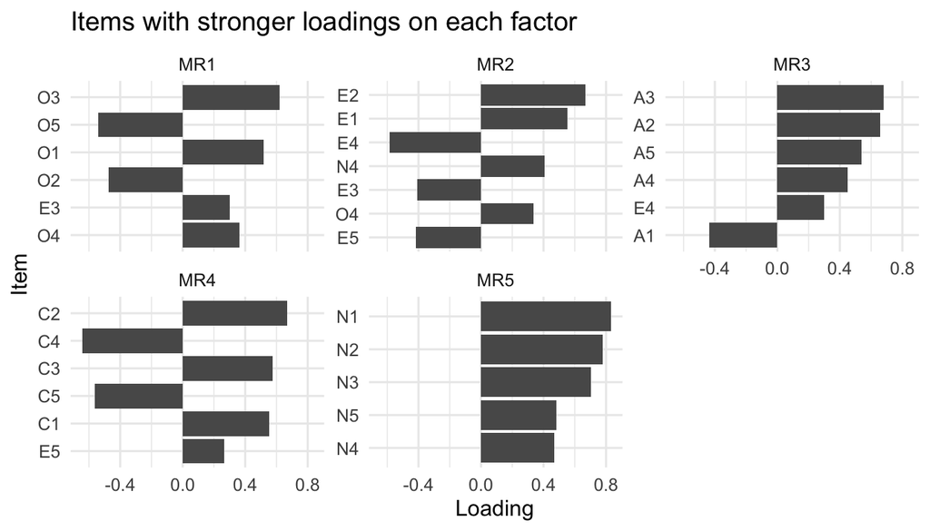

```r
loadings_long %>%
  dplyr::filter(abs(loading) > 0.25) %>%
  ggplot(aes(x = reorder(item, abs(loading)), y = loading)) +
  geom_col() +
  coord_flip() +
  facet_wrap(~ factor, scales = "free_y") +
  labs(
    title = "Items with stronger loadings on each factor",
    x = "Item",
    y = "Loading"
  )
```

This plot helps students see which items define each factor.

Positive and negative loadings both matter. A negative loading does not mean the item is unimportant. It means the item is related to the factor in the opposite direction.

# 11 Factor correlations

## 11.1 Inspect factor correlations

Because we used oblimin rotation, the factors are allowed to correlate.

```r
efa_fit$Phi
```

```
##              MR5        MR2        MR4         MR3          MR1
## MR5  1.000000000  0.2169455 -0.1908937 -0.04621711 -0.001483828
## MR2  0.216945475  1.0000000 -0.2365136 -0.32969981 -0.166401016
## MR4 -0.190893726 -0.2365136  1.0000000  0.20206082  0.197941058
## MR3 -0.046217113 -0.3296998  0.2020608  1.00000000  0.195531954
## MR1 -0.001483828 -0.1664010  0.1979411  0.19553195  1.000000000
```

If the factor correlations are small, an orthogonal rotation such as `varimax` might give a similar interpretation.

If the factor correlations are moderate or large, oblique rotation is usually more realistic.

# 12 Factor scores

## 12.1 What are factor scores?

Factor scores estimate each respondent’s position on each latent factor.

They are not directly observed values. They are estimated from the pattern of item responses.

Factor scores can be useful for:

- plotting respondents in lower-dimensional space;
- using factors in later analyses;
- summarising questionnaire responses.

However, they should be interpreted with care because they are estimated quantities, not raw measurements.

```r
factor_scores <- tibble::as_tibble(efa_fit$scores)

head(factor_scores)
```

```
## # A tibble: 6 × 5
##      MR5     MR2     MR4     MR3    MR1
##    <dbl>   <dbl>   <dbl>   <dbl>  <dbl>
## 1 -0.222 -0.128  -1.33   -0.855  -1.61
## 2  0.162 -0.466  -0.572  -0.0724 -0.172
## 3  0.619 -0.141  -0.0429 -0.552   0.233
## 4 -0.117 -0.0581 -1.06   -0.0906 -1.06
## 5 -0.174 -0.460  -0.0995 -0.712  -0.661
## 6  0.193 -1.09    1.40    0.389   0.624
```

## 12.2 Plot factor scores

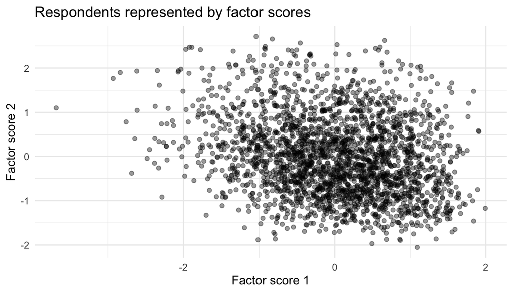

```r
factor_scores %>%
  ggplot(aes(x = MR1, y = MR2)) +
  geom_point(alpha = 0.4) +
  labs(
    title = "Respondents represented by factor scores",
    x = "Factor score 1",
    y = "Factor score 2"
  )
```

Each point represents one respondent. Respondents close together have similar estimated scores on the first two factors.

# 13 Practical exercise

## 13.1 Exercise: compare factor solutions

1. Fit a 4-factor solution.
2. Fit a 6-factor solution.
3. Compare the interpretability of the loadings.
4. Which solution would you report and why?

```r
efa_4 <- psych::fa(
  bfi_items,
  nfactors = 4,
  fm = "minres",
  rotate = "oblimin"
)

efa_6 <- psych::fa(
  bfi_items,
  nfactors = 6,
  fm = "minres",
  rotate = "oblimin"
)

print(efa_4$loadings, cutoff = 0.3)
print(efa_6$loadings, cutoff = 0.3)
```

[output not shown]

# 14 Exercise solution

## 14.1 Fit alternative factor solutions

## 14.2 Compare loadings

When comparing the loading tables, ask:

- Are there factors with several strong loadings?
- Are the strong loadings conceptually coherent?
- Are there many cross-loadings?
- Are there factors with only one strong item?
- Does the factor solution make substantive sense?

```r
#Fit statistics can help compare solutions, but they should not replace interpretation.

#A solution with more factors may fit better statistically, but it may also be harder to explain or may produce factors that are not meaningful.
```

```r
## Which solution would you report?

#I would usually start with the solution suggested by parallel analysis, then check whether the loadings are interpretable. For the `bfi` data, a five-factor solution is substantively meaningful because the items were designed around five broad personality domains. A four-factor solution may combine constructs that should be separate, while a six-factor solution may split one construct or create a less interpretable extra factor.

#In applied work, the decision should be based on both statistical evidence and substantive theory.
```

# 15 Summary

In this session, we used exploratory factor analysis to explore latent structure in questionnaire-style item data.

Key points:

- EFA is used when observed variables may reflect latent constructs.
- EFA focuses on shared variance among variables.
- PCA and EFA are related but answer different questions.
- Correlation structure is central to factor analysis.
- Parallel analysis helps choose the number of factors.
- Rotation helps make loadings easier to interpret.
- Oblique rotation allows factors to be correlated.
- Loadings describe relationships between items and factors.
- Factor scores estimate respondent positions on latent factors.
- The final factor solution should be interpretable, not just statistically convenient.

# 16 Transition

This optional session extends the multivariate methods theme from observed variables to latent constructs.

PCA, clustering, LDA, NMDS and EFA all reduce or structure multivariate data, but they answer different questions:

| Method | Main question |
| --- | --- |
| PCA | What are the main axes of variation in continuous variables? |
| Clustering | Do observations naturally group together? |
| LDA | Can known groups be predicted from multivariate traits? |
| NMDS | Which sites are similar in community composition? |
| EFA | Can observed item correlations be explained by latent factors? |